# Exam 3

Philip Dominici

May 1, 2016

# Introduction

Read in and get familiar with the data:

```r
macro <- read.csv("./macro.csv")
#macro <- read.csv("./Schoolwork/36402/macro.csv")
head(macro)
```

```
##            X         GDP Consumption  Investment      Hours Productivity
## 1 1947-03-31 -0.09513014 -0.04363307 -0.07014098 0.07418562   -0.1700505
## 2 1947-06-30 -0.10427008 -0.03568519 -0.15967643 0.06981641   -0.1539451
## 3 1947-09-30 -0.11329526 -0.04091760 -0.19893601 0.07467100   -0.1619903
## 4 1947-12-31 -0.10568157 -0.04917999 -0.03178313 0.07934403   -0.1661547
## 5 1948-03-31 -0.09909193 -0.05263338  0.05609577 0.07128502   -0.1267373
## 6 1948-06-30 -0.09098666 -0.04958016  0.10667469 0.06872671   -0.1123006
```

```r
tail(macro)
```

```
##              X        GDP Consumption Investment       Hours Productivity
## 272 2014-12-31 -0.1429087  -0.1300980 -0.1615548 -0.06043999  -0.03386190
## 273 2015-03-31 -0.1493145  -0.1342736 -0.1505993 -0.05927952  -0.04346191
## 274 2015-06-30 -0.1477100  -0.1340031 -0.1480905 -0.05835273  -0.04592664
## 275 2015-09-30 -0.1508065  -0.1350691 -0.1595147 -0.06183835  -0.04714191
## 276 2015-12-31 -0.1553713  -0.1375306 -0.1716079 -0.05653438           NA
## 277 2016-03-31 -0.1620326  -0.1414155 -0.1902294          NA           NA
```

```r
macro$X <- as.Date(macro$X)
```

# 1: A Model for Base Data

## Comparisons

To determine which regression model to use here, we compare the error measurements of different techniques. Specifically, we check the mean squared errors and residual plots of generalized linear regression (gaussian family) and kernel regression. It is immediately apparent from the following residual plots that the residuals of kernel regression are much more evenly distributed on either side of the line, and that they suffer less change in spread across the graph (even though larger fitted values seem to be somewhat more variable). Numerical computation of the mean squared errors also reveals that kernel regression has much smaller errors overall, by a magnitude of 10^2.

```r
library(np)

macro2005 <- subset(macro, X < "2006-01-01")

#Linear Regression
mac2005reg <- glm(GDP ~ Consumption+Investment+Hours+Productivity,
                 data=macro2005)

kreg.macro <- npreg(GDP ~ Consumption+Investment+Hours+Productivity,
                  data=macro2005)
```

[output not shown]

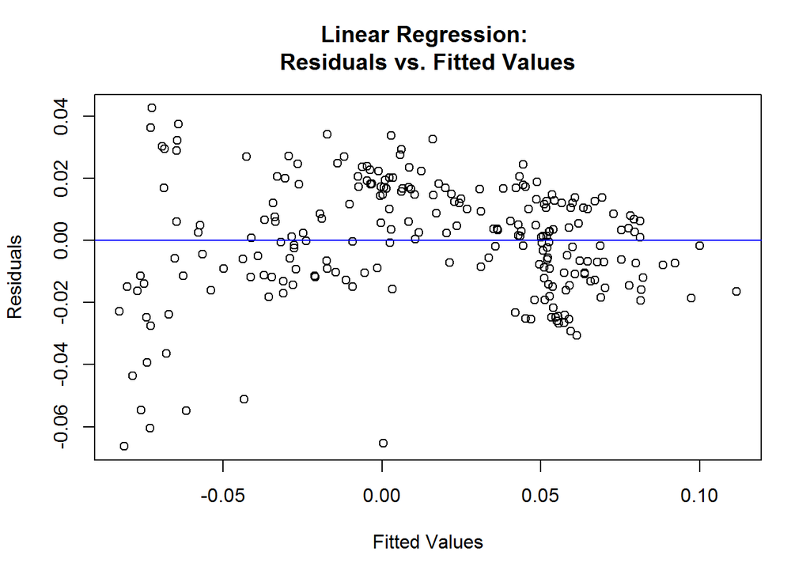

```r
#residuals for lm
plot(y=residuals(mac2005reg), x=fitted(mac2005reg), main="Linear Regression: \nResiduals vs. Fitted Values", xlab="Fitted Values", ylab="Residuals")
abline(h=0, col="blue")
```

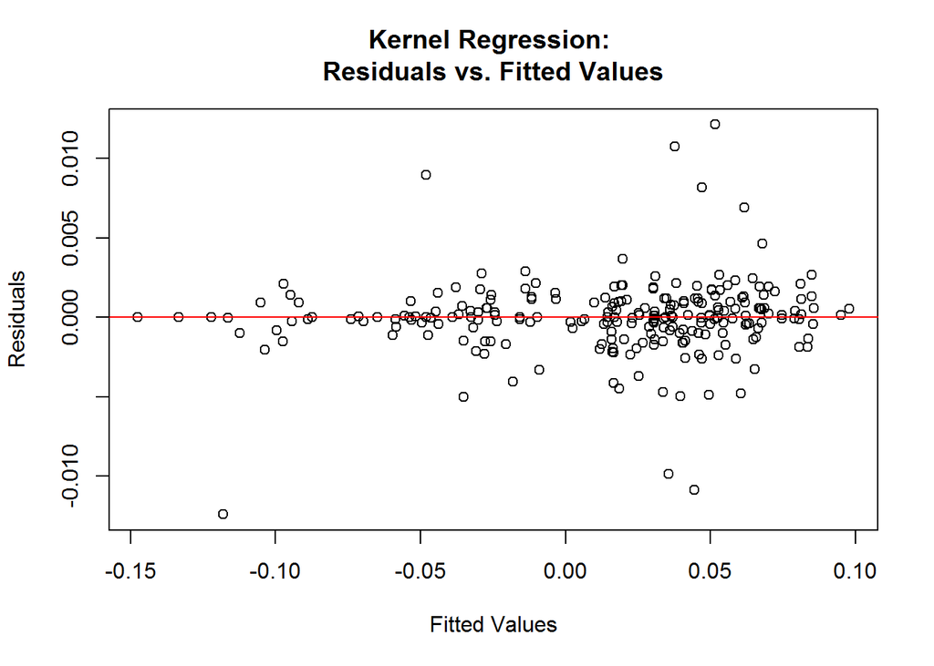

```r
#residuals for kernel
plot(y=residuals(kreg.macro), x=fitted(kreg.macro), main="Kernel Regression: \nResiduals vs. Fitted Values", xlab="Fitted Values", ylab="Residuals")
abline(h=0, col="red")
```

```r
#compare MSEs
options("scipen"=100, "digits"=4) #dont want exponent form
kreg.macro$MSE #kernel mse
```

```
## [1] 0.000005867
```

```r
mean(mac2005reg$residuals^2) #lm mse
```

```
## [1] 0.0003507
```

## Performance on Training Data

```r
kreg.macro$bw
```

```
## [1] 0.005459 0.044641 0.006830 0.005511
```

```r
summary(kreg.macro)
```

```
##
## Regression Data: 236 training points, in 4 variable(s)
##               Consumption Investment   Hours Productivity
## Bandwidth(s):    0.005459    0.04464 0.00683     0.005511
##
## Kernel Regression Estimator: Local-Constant
## Bandwidth Type: Fixed
## Residual standard error: 0.002422
## R-squared: 0.9978
##
## Continuous Kernel Type: Second-Order Gaussian
## No. Continuous Explanatory Vars.: 4
```

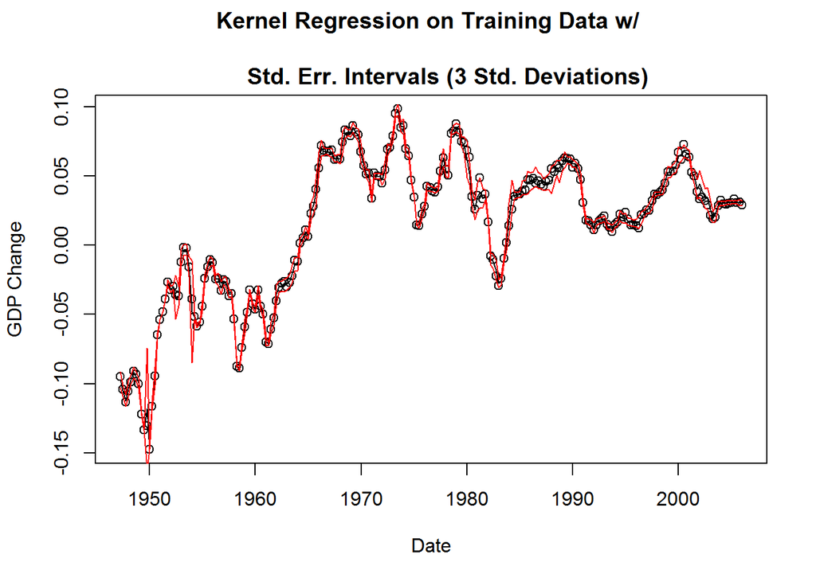

```r
plot(macro2005$X, macro2005$GDP, main="Kernel Regression on Training Data w/ \n
     Std. Err. Intervals (3 Std. Deviations)", xlab="Date", ylab="GDP Change")
lines(macro2005$X, kreg.macro$mean, col="black")
lines(macro2005$X, kreg.macro$mean+3*kreg.macro$merr, col='red')
lines(macro2005$X, kreg.macro$mean-3*kreg.macro$merr, col='red')
```

## Prediction Performances

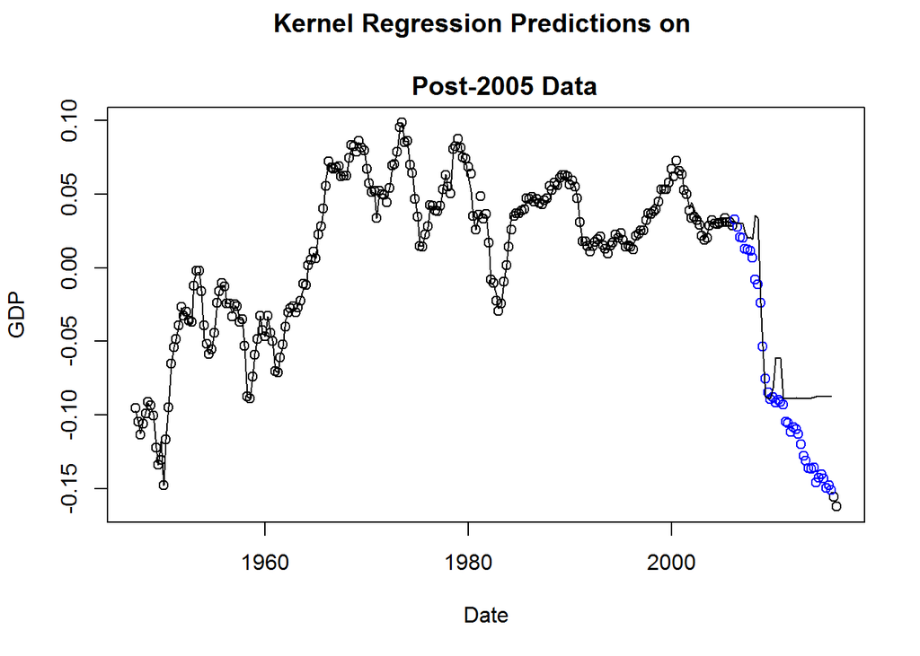

```r
post2005 <- na.omit(subset(macro, X > "2006-01-01"))
predicted <- predict(kreg.macro, newdata=post2005[, 3:6])

plot(macro$X, macro$GDP, main="Kernel Regression Predictions on \n
     Post-2005 Data", xlab="Date", ylab="GDP")
lines(macro2005$X, kreg.macro$mean, col="black")
points(post2005$X, post2005$GDP, col="blue")
lines(post2005$X, predicted)
```

# 2: A Model for Lagged Data

## Comparisons

A new data frame is created to contain the data in lagged form, and again different models are compared on the merit of their error rates.  
We can see that this time the generalized linear model (gaussian family) performs better it did than before relative to the kernel regression, with a much more even/less shaped spread in the residual plot and a MSE only slightly larger than the MSE of the kernel regression. The kernel regression, in turn, has a higher MSE than before, but seems to have improved in the residual plot with much less change in distribution of residuals for increasing fitted values. For the sake of comparison and since its MSE is still smaller, we will stick with kernel regression again here.

```r
macroDelay <- macro[1:nrow(macro)-1,2:6]
macroDelay$GDP <- macro$GDP[2:nrow(macro)]
macroDelay$oldGDP <- macro$GDP[1:nrow(macro)-1]
macroDelay$X <- macro$X[2:nrow(macro)]

macro2005delay <- na.omit(subset(macroDelay, X < "2006-01-01"))
macroPost2005Delay <- na.omit(subset(macroDelay, X > "2006-01-01"))

#Linear Model
mac2005delayReg <- glm(GDP ~ Consumption+Investment+Hours+oldGDP,
                      data=macro2005delay)

#Kernel Model
kreg.delay <- npreg(GDP ~ Consumption+Investment+Hours+oldGDP,
                  data=macro2005delay)
```

[output not shown]

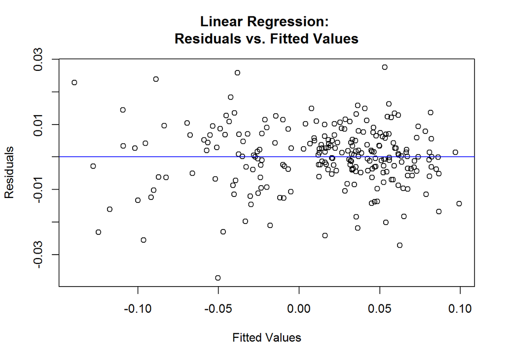

```r
#residuals for lm
plot(y=residuals(mac2005delayReg), x=fitted(mac2005delayReg), main="Linear Regression: \nResiduals vs. Fitted Values", xlab="Fitted Values", ylab="Residuals")
abline(h=0, col="blue")
```

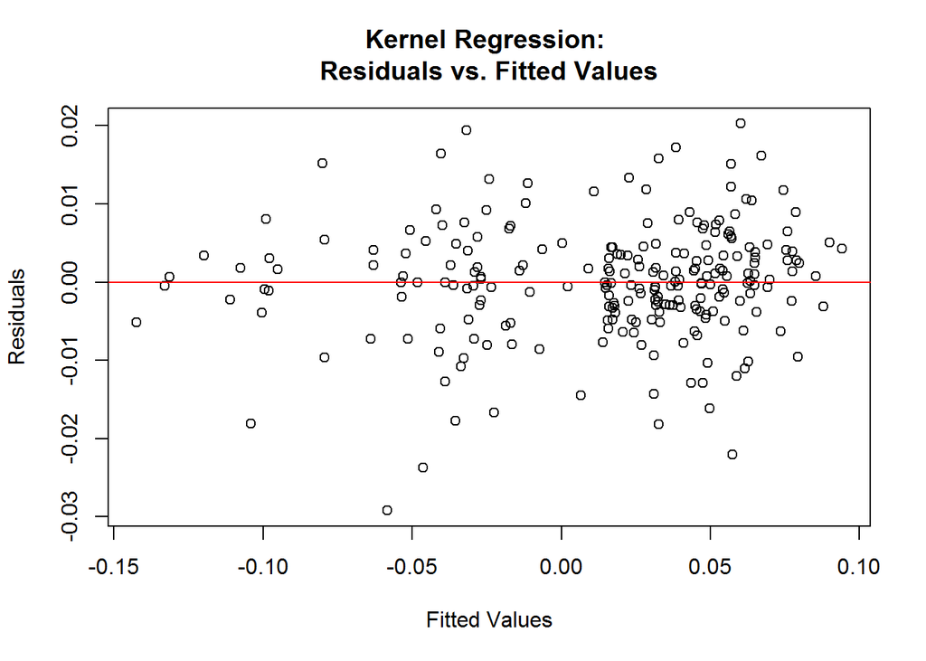

```r
#residuals for kernel
plot(y=residuals(kreg.delay), x=fitted(kreg.delay), main="Kernel Regression: \nResiduals vs. Fitted Values", xlab="Fitted Values", ylab="Residuals")
abline(h=0, col="red")
```

```r
#compare MSEs
mean(mac2005delayReg$residuals^2) #lm mse
```

```
## [1] 0.00008885
```

```r
kreg.delay$MSE #kernel mse
```

```
## [1] 0.00005357
```

## Performance on Training Data

Again, we look at how the kernel model fits the data. At bandwidths of 0.0077, 0.0486, 22164, and 0.0081 for the consumption, investment, hours, and oldGDP variables at time t, we get the following output model. What is immediately clear in the output is that the “hours” variable has a massive bandwidth value, and is surely smoothed to the point of irrelevance. We might conclude that “hours” is thus not very influential/significant to the model. The other 3 predictive variables do seem to be important to the model. A plot of the kernel regression line and its standard error bounds at 3 standard deviations is shown as well. We can see that the majority of points are captured by within 3 standard deviations of the model, and that the error margin is again quite small in some places. We do see, however, that the error intervals and curve itself are much smoother in nature than before, without the spikes at peaks/dips present in the previous model. We might conclude that some overfitting is still occurring, but less overall.

```r
kreg.delay$bw
```

```
## [1]     0.007716     0.048620 22163.589645     0.008106
```

```r
summary(kreg.delay)
```

```
##
## Regression Data: 235 training points, in 4 variable(s)
##               Consumption Investment Hours   oldGDP
## Bandwidth(s):    0.007716    0.04862 22164 0.008106
##
## Kernel Regression Estimator: Local-Constant
## Bandwidth Type: Fixed
## Residual standard error: 0.007319
## R-squared: 0.9795
##
## Continuous Kernel Type: Second-Order Gaussian
## No. Continuous Explanatory Vars.: 4
```

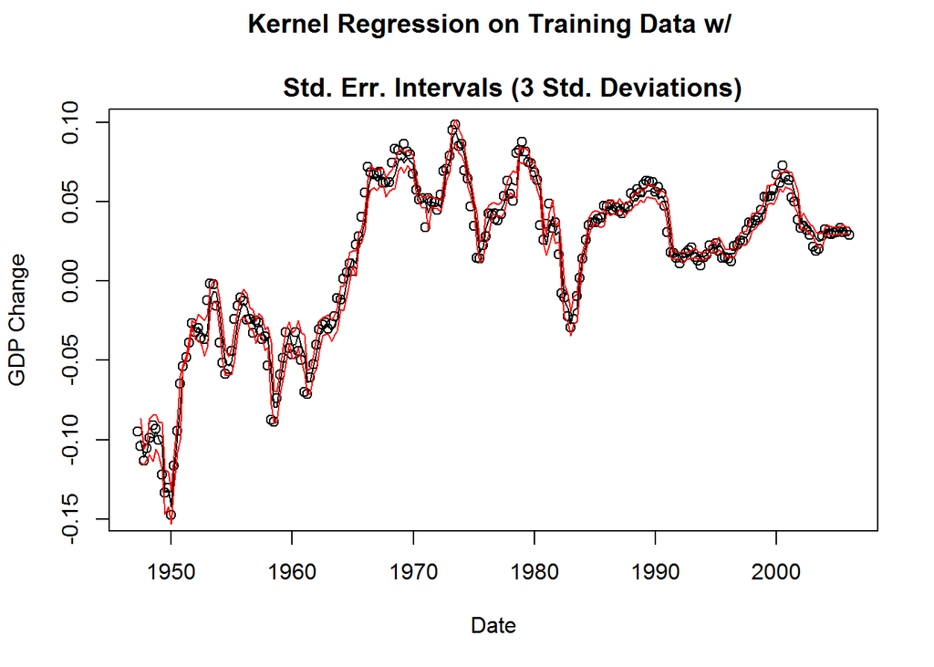

```r
plot(macro2005$X, macro2005$GDP, main="Kernel Regression on Training Data w/ \n
     Std. Err. Intervals (3 Std. Deviations)", xlab="Date", ylab="GDP Change")
lines(macro2005$X[-1], kreg.delay$mean, col="black")
lines(macro2005$X[-1], kreg.delay$mean+3*kreg.delay$merr, col='red')
lines(macro2005$X[-1], kreg.delay$mean-3*kreg.delay$merr, col='red')
```

## Prediction Performances

Finally, we get to predicting the post-2005 points based on the new model. From the plot it is right away clear that this kernel regression is doing a significantly better job than the last one, with the line following the decrease until the end of the data. Close observation shows that the prediction line does even out a little towards the end, but this is not nearly as much of an issue as before. A quick calculation of the predicted points mean squared error yields 0.00022, which is perfectly reasonable.

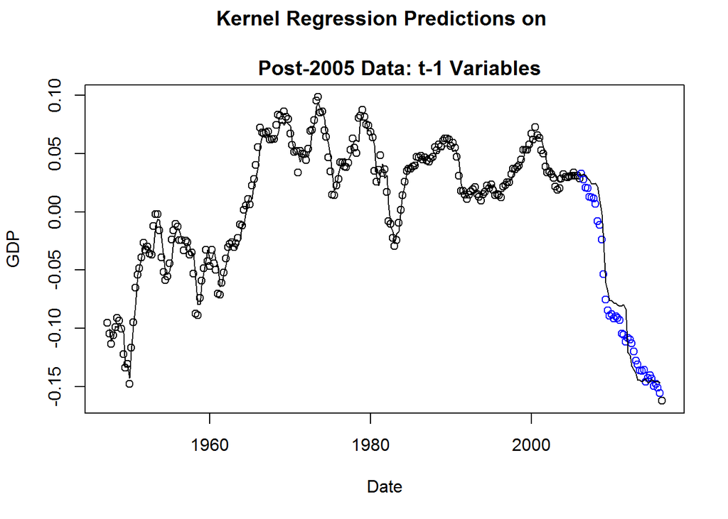

```r
predicted <- predict(kreg.delay, newdata=macroPost2005Delay)

plot(macro$X, macro$GDP, main="Kernel Regression Predictions on \n
     Post-2005 Data: t-1 Variables", xlab="Date", ylab="GDP")
lines(macro2005delay$X, kreg.delay$mean, col="black")
points(macroPost2005Delay$X, macroPost2005Delay$GDP, col="blue")
lines(macroPost2005Delay$X, predicted)
```

```r
mean((predicted - macroPost2005Delay$GDP)^2)
```

```
## [1] 0.0002151
```

# 3: Testing the Productivity Variable as a Predictor

## Comparisons (now with Productivity!)

When comparing the models with and without the Productivity variable, we start, as usual, with the residual plots. In both plots we see that the residuals with and without Productivity included for both linear and kernel regressions are roughly the same. A quick comparison of the MSEs of the linear/kernel models with/out Productivity confirms that the change in errors is minimal.

```r
#Linear Model
mac2005dAllReg <- glm(GDP ~ Consumption+Investment+Hours+oldGDP+Productivity,
                      data=macro2005delay)

#Kernel Model
kreg.delayAll <- npreg(GDP ~ Consumption+Investment+Hours+oldGDP+Productivity,
                  data=macro2005delay)
```

[output not shown]

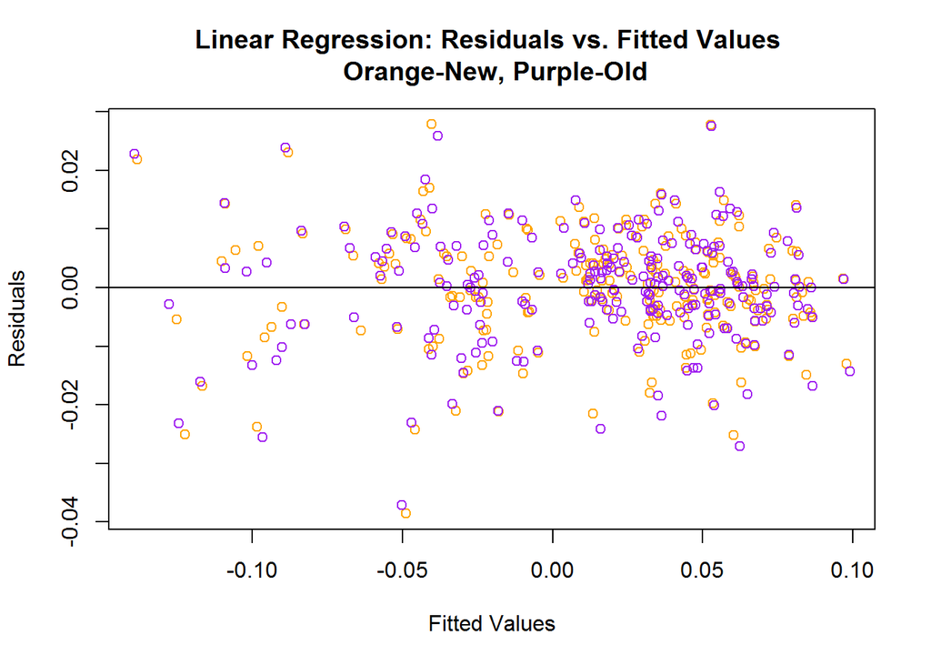

```r
#residuals for lm
plot(y=residuals(mac2005dAllReg), x=fitted(mac2005dAllReg), col="orange", main="Linear Regression: Residuals vs. Fitted Values \n Orange-New, Purple-Old", xlab="Fitted Values", ylab="Residuals")
points(y=residuals(mac2005delayReg), x=fitted(mac2005delayReg), col="purple")
abline(h=0)
```

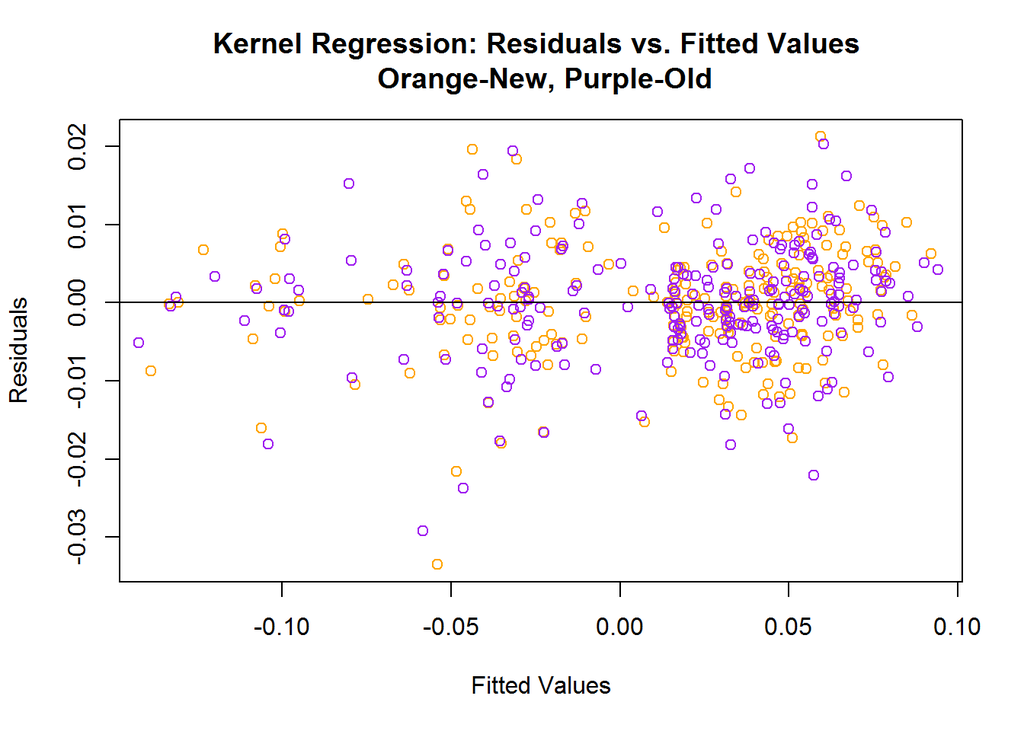

```r
#residuals for kernel
plot(y=residuals(kreg.delayAll), x=fitted(kreg.delayAll), main="Kernel Regression: Residuals vs. Fitted Values \n Orange-New, Purple-Old", xlab="Fitted Values", ylab="Residuals", col="orange")
points(y=residuals(kreg.delay), x=fitted(kreg.delay), col="purple")
abline(h=0)
```

```r
#compare MSEs
paste("Linear Reg. MSE w/ Prod.", mean(mac2005dAllReg$residuals^2))
```

```
## [1] "Linear Reg. MSE w/ Prod. 0.0000869134934581037"
```

```r
paste("Linear Reg. MSE w/o Prod.: ", mean(mac2005delayReg$residuals^2)) #lm
```

```
## [1] "Linear Reg. MSE w/o Prod.:  0.0000888543335599635"
```

```r
paste("Kernel Reg. MSE w/ Prod.: ", kreg.delayAll$MSE)
```

```
## [1] "Kernel Reg. MSE w/ Prod.:  0.0000505675833517203"
```

```r
paste("Kernel Reg. MSE w/o Prod.: ", kreg.delay$MSE) #kernel mse
```

```
## [1] "Kernel Reg. MSE w/o Prod.:  0.0000535733205271419"
```

## Performance on Training Data

Again, for the sake of comparison, we will look at the kernel regression models and compare the presence of Productivity to the absence of it. A quick comparison of bandwidths, as shown below, reveals that the addition of Productivity gives relevance to the Hours variable in the new model; whereas the old model had a bandwidth of over 20000, making Hours effectively irrelevant, the new model has a much more reasonable bandwidth of 0.0253 for Hours. This comes slightly at the expense of Consumption, Investment, and oldGDP, which each roughly double in bandwidth (but are still relevant). From this we might gather that Hours is correlated with Productivity, and that an interaction term may be relevant in future models. A simple plotting of the two kernel regressions on the pre-2005 data shows the curves are pretty similar, and that the Production-added model is just slightly smoother in shape.  
Since it would be unclear to plot both sets of confidence intervals on the same full graphic, we will instead plot the standard errors alone. In this plot we see that the error rates match pretty closely for both models.

```r
kreg.delay$bws
```

```
##
## Regression Data (235 observations, 4 variable(s)):
##
##               Consumption Investment Hours   oldGDP
## Bandwidth(s):    0.007716    0.04862 22164 0.008106
##
## Regression Type: Local-Constant
## Bandwidth Selection Method: Least Squares Cross-Validation
## Formula: GDP ~ Consumption + Investment + Hours + oldGDP
## Bandwidth Type: Fixed
## Objective Function Value: 0.00009841 (achieved on multistart 1)
##
## Continuous Kernel Type: Second-Order Gaussian
## No. Continuous Explanatory Vars.: 4
```

```r
kreg.delayAll$bws
```

```
##
## Regression Data (235 observations, 5 variable(s)):
##
##               Consumption Investment   Hours  oldGDP Productivity
## Bandwidth(s):      0.0149     0.0833 0.02537 0.01729      0.01757
##
## Regression Type: Local-Constant
## Bandwidth Selection Method: Least Squares Cross-Validation
## Formula: GDP ~ Consumption + Investment + Hours + oldGDP + Productivity
## Bandwidth Type: Fixed
## Objective Function Value: 0.00009055 (achieved on multistart 2)
##
## Continuous Kernel Type: Second-Order Gaussian
## No. Continuous Explanatory Vars.: 5
```

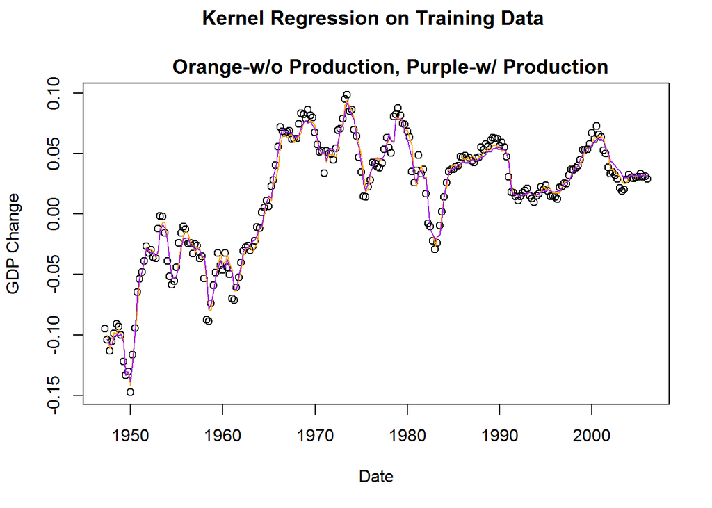

```r
plot(macro2005$X, macro2005$GDP, main="Kernel Regression on Training Data \n
     Orange-w/o Production, Purple-w/ Production", xlab="Date", ylab="GDP Change")
lines(macro2005$X[-1], kreg.delay$mean, col="orange")
lines(macro2005$X[-1], kreg.delayAll$mean, col="purple")
```

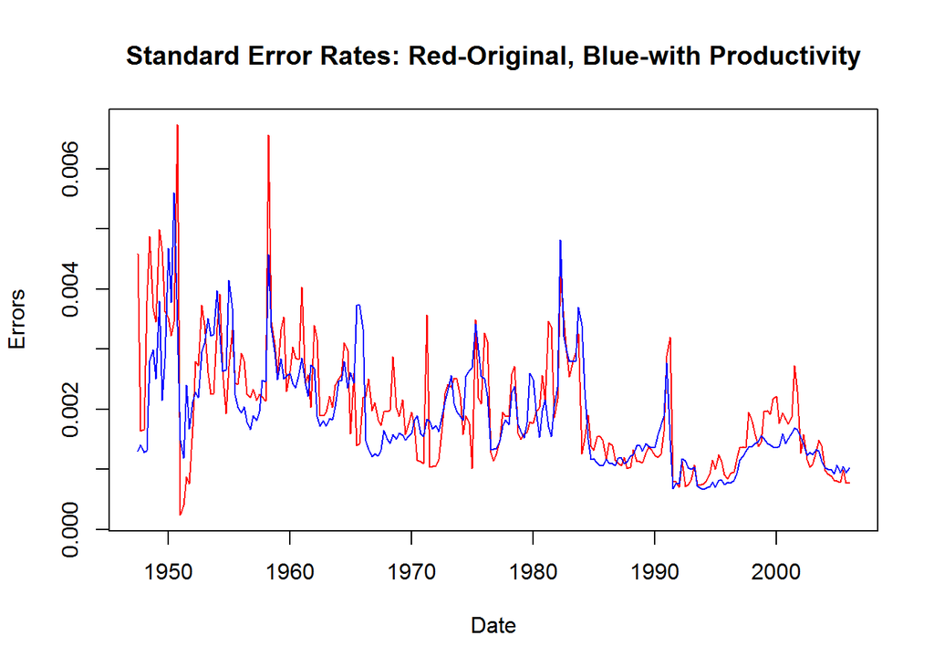

```r
plot(macro2005$X[-1], kreg.delay$merr, type="l", col="red",
     main="Standard Error Rates: Red-Original, Blue-with Productivity",
     xlab="Date", ylab="Errors")
lines(macro2005$X[-1], kreg.delayAll$merr, col="blue")
```

## Prediction Performances

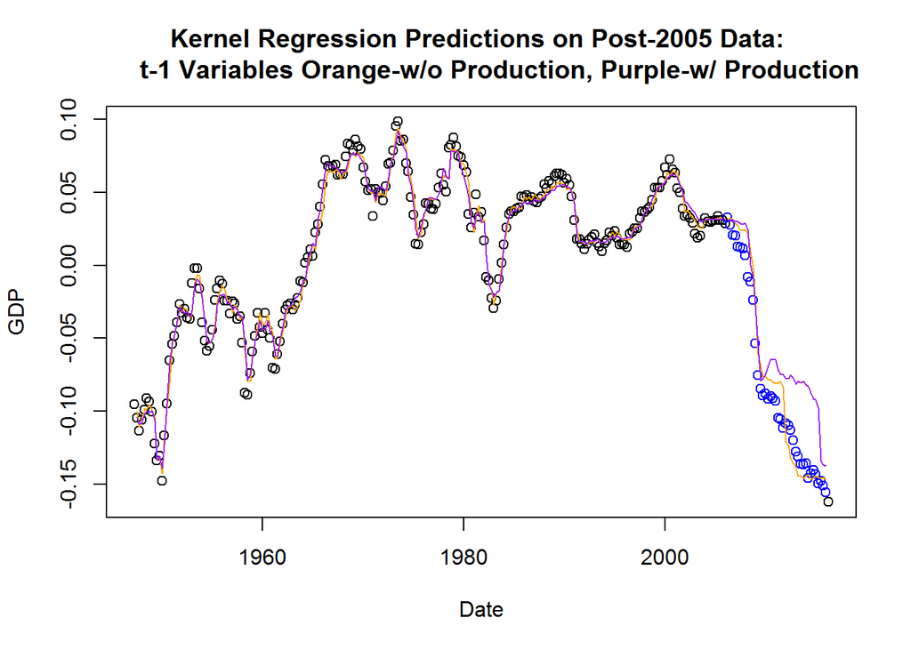

```r
predictedAll <- predict(kreg.delayAll, newdata=macroPost2005Delay)

plot(macro$X, macro$GDP, main="Kernel Regression Predictions on Post-2005 Data:
     t-1 Variables Orange-w/o Production, Purple-w/ Production",
     xlab="Date", ylab="GDP")
lines(macro2005delay$X, kreg.delay$mean, col="orange")
lines(macro2005delay$X, kreg.delayAll$mean, col="purple")
points(macroPost2005Delay$X, macroPost2005Delay$GDP, col="blue")
lines(macroPost2005Delay$X, predicted, col="orange")
lines(macroPost2005Delay$X, predictedAll, col="purple")
```

Overall, we can conclude from our findings that Productivity gives meaning to the Hours variable and helps smooth the model overall, but that Productivity actually worsens predictions when trained on the pre-2005 data. This indicates that the addition of this variable increases overfitting to some extent. It should not be taken away from this that productivity drives GDP on its own, at least not in the presence of the other variables utilized, even if Productivity does clearly have some effect on GDP.

# 4: Additive Regressions

Note that for both problems 4 and 5, we will continue to use pre-2005 data to train the models.

Summaries of the additive models are given below, including significance levels of the smoothed variables used. We can see that smoothed Productivity is significant when predicting future GDP (0.001 alpha), Investment (0.001 alpha), and Hours (0.1 alpha) levels, but not when predicting Consumption. Since Productivity is significant in predicting the future GDP model, these findings do support the theory that productivity drives GDP to some extent.

```r
library(mgcv)

addGDP <- gam(GDP ~ s(oldGDP)+s(Consumption)+s(Investment)+s(Hours)+s(Productivity),
              data=macro2005delay)

macro2005delay$newConsumption <- macro2005$Consumption[2:nrow(macro2005)]
addConsumption <- gam(newConsumption ~ s(oldGDP)+s(Consumption)+s(Investment)+s(Hours)+s(Productivity),
                      data=macro2005delay)

macro2005delay$newInvestment <- macro2005$Investment[2:nrow(macro2005)]
addInvestment <- gam(newInvestment ~ s(oldGDP)+s(Consumption)+s(Investment)+s(Hours)+s(Productivity),
                     data=macro2005delay)

macro2005delay$newHours <- macro2005$Hours[2:nrow(macro2005)]
addHours <- gam(newHours ~ s(oldGDP)+s(Consumption)+s(Investment)+s(Hours)+s(Productivity),
                data=macro2005delay)

summary(addGDP)
```

```
##
## Family: gaussian
## Link function: identity
##
## Formula:
## GDP ~ s(oldGDP) + s(Consumption) + s(Investment) + s(Hours) +
##     s(Productivity)
##
## Parametric coefficients:
##             Estimate Std. Error t value            Pr(>|t|)
## (Intercept) 0.014994   0.000582    25.8 <0.0000000000000002 ***
## ---
## Signif. codes:  0 '***' 0.001 '**' 0.01 '*' 0.05 '.' 0.1 ' ' 1
##
## Approximate significance of smooth terms:
##                  edf Ref.df      F              p-value
## s(oldGDP)       2.35   2.99 143.03 < 0.0000000000000002 ***
## s(Consumption)  6.48   7.61   3.31              0.00169 **
## s(Investment)   1.00   1.00   0.37              0.54523
## s(Hours)        1.61   1.97   2.60              0.10354
## s(Productivity) 4.31   5.32   4.19              0.00092 ***
## ---
## Signif. codes:  0 '***' 0.001 '**' 0.01 '*' 0.05 '.' 0.1 ' ' 1
##
## R-sq.(adj) =  0.969   Deviance explained = 97.1%
## GCV = 8.5609e-05  Scale est. = 7.9508e-05  n = 235
```

```r
summary(addConsumption)
```

```
##
## Family: gaussian
## Link function: identity
##
## Formula:
## newConsumption ~ s(oldGDP) + s(Consumption) + s(Investment) +
##     s(Hours) + s(Productivity)
##
## Parametric coefficients:
##             Estimate Std. Error t value            Pr(>|t|)
## (Intercept) 0.012165   0.000519    23.4 <0.0000000000000002 ***
## ---
## Signif. codes:  0 '***' 0.001 '**' 0.01 '*' 0.05 '.' 0.1 ' ' 1
##
## Approximate significance of smooth terms:
##                  edf Ref.df      F             p-value
## s(oldGDP)       4.87   5.98   2.23               0.042 *
## s(Consumption)  2.88   3.63 123.10 <0.0000000000000002 ***
## s(Investment)   1.00   1.00   0.85               0.357
## s(Hours)        2.61   3.24   1.64               0.209
## s(Productivity) 2.66   3.32   0.56               0.595
## ---
## Signif. codes:  0 '***' 0.001 '**' 0.01 '*' 0.05 '.' 0.1 ' ' 1
##
## R-sq.(adj) =  0.964   Deviance explained = 96.6%
## GCV = 6.7658e-05  Scale est. = 6.3334e-05  n = 235
```

```r
summary(addInvestment)
```

```
##
## Family: gaussian
## Link function: identity
##
## Formula:
## newInvestment ~ s(oldGDP) + s(Consumption) + s(Investment) +
##     s(Hours) + s(Productivity)
##
## Parametric coefficients:
##             Estimate Std. Error t value            Pr(>|t|)
## (Intercept)  0.02479    0.00277    8.96 <0.0000000000000002 ***
## ---
## Signif. codes:  0 '***' 0.001 '**' 0.01 '*' 0.05 '.' 0.1 ' ' 1
##
## Approximate significance of smooth terms:
##                  edf Ref.df     F              p-value
## s(oldGDP)       3.48   4.42  6.44           0.00003811 ***
## s(Consumption)  7.77   8.59  5.93           0.00000025 ***
## s(Investment)   4.87   6.03 31.15 < 0.0000000000000002 ***
## s(Hours)        5.09   6.22  4.41              0.00028 ***
## s(Productivity) 3.06   3.82  5.61              0.00043 ***
## ---
## Signif. codes:  0 '***' 0.001 '**' 0.01 '*' 0.05 '.' 0.1 ' ' 1
##
## R-sq.(adj) =  0.861   Deviance explained = 87.5%
## GCV = 0.0020137  Scale est. = 0.0017971  n = 235
```

```r
summary(addHours)
```

```
##
## Family: gaussian
## Link function: identity
##
## Formula:
## newHours ~ s(oldGDP) + s(Consumption) + s(Investment) + s(Hours) +
##     s(Productivity)
##
## Parametric coefficients:
##             Estimate Std. Error t value            Pr(>|t|)
## (Intercept) 0.008671   0.000534    16.2 <0.0000000000000002 ***
## ---
## Signif. codes:  0 '***' 0.001 '**' 0.01 '*' 0.05 '.' 0.1 ' ' 1
##
## Approximate significance of smooth terms:
##                  edf Ref.df      F              p-value
## s(oldGDP)       1.03   1.07  13.32              0.00027 ***
## s(Consumption)  7.31   8.30   3.75              0.00026 ***
## s(Investment)   2.07   2.64   1.30              0.22060
## s(Hours)        3.49   4.33 248.71 < 0.0000000000000002 ***
## s(Productivity) 7.24   8.25   1.87              0.09419 .
## ---
## Signif. codes:  0 '***' 0.001 '**' 0.01 '*' 0.05 '.' 0.1 ' ' 1
##
## R-sq.(adj) =  0.971   Deviance explained = 97.4%
## GCV = 7.3895e-05  Scale est. = 6.6932e-05  n = 235
```

# 5: Estimating a First-Order Autoregressive Model for Productivity

AAR functions and dependencies.

```r
design.matrix.from.ts <- function(ts, order, right.older = TRUE) {
  n <- length(ts)
  x <- ts[(order + 1):n]
  for (lag in 1:order) {
    if (right.older) {
      x <- cbind(x, ts[(order + 1 - lag):(n - lag)])
    }
    else {
      x <- cbind(ts[(order + 1 - lag):(n - lag)], x)
    }
  }
  lag.names <- c("lag0", paste("lag", 1:order, sep = ""))
  if (right.older) {
    colnames(x) <- lag.names
  }
  else {
    colnames(x) <- rev(lag.names)
  }
  return(as.data.frame(x))
}

aar <- function(ts, family=gaussian(), order) {
  stopifnot(require(mgcv))
  fit <- gam(as.formula(auto.formula(order)),
             data=design.matrix.from.ts(ts, order), family=family)
  return(fit)
}
auto.formula <- function(order) {
  inputs <- paste("s(lag", 1:order, ")", sep = "", collapse = "+")
  form <- paste("lag0 ~ ", inputs)
return(form)
}
```

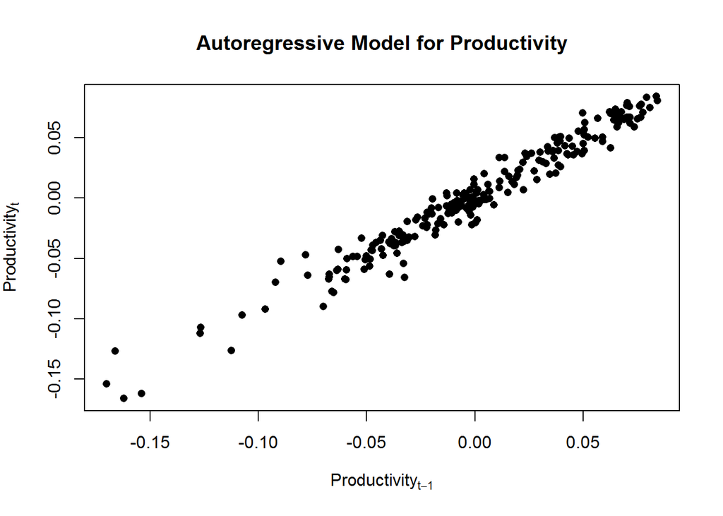

```r
plot(lag0 ~ lag1, data = design.matrix.from.ts(macro2005$Productivity, 1),
     xlab = expression(Productivity[t-1]),
     ylab = expression(Productivity[t]), pch = 16,
     main="Autoregressive Model for Productivity")
```

```r
prod.aar1 <- aar(macro2005$Productivity, family=gaussian(), 1)
summary(prod.aar1)
```

```
##
## Family: gaussian
## Link function: identity
##
## Formula:
## lag0 ~ s(lag1)
##
## Parametric coefficients:
##             Estimate Std. Error t value Pr(>|t|)
## (Intercept) 0.001578   0.000629    2.51    0.013 *
## ---
## Signif. codes:  0 '***' 0.001 '**' 0.01 '*' 0.05 '.' 0.1 ' ' 1
##
## Approximate significance of smooth terms:
##          edf Ref.df    F             p-value
## s(lag1) 1.87   2.35 2497 <0.0000000000000002 ***
## ---
## Signif. codes:  0 '***' 0.001 '**' 0.01 '*' 0.05 '.' 0.1 ' ' 1
##
## R-sq.(adj) =  0.962   Deviance explained = 96.2%
## GCV = 9.4132e-05  Scale est. = 9.2981e-05  n = 235
```

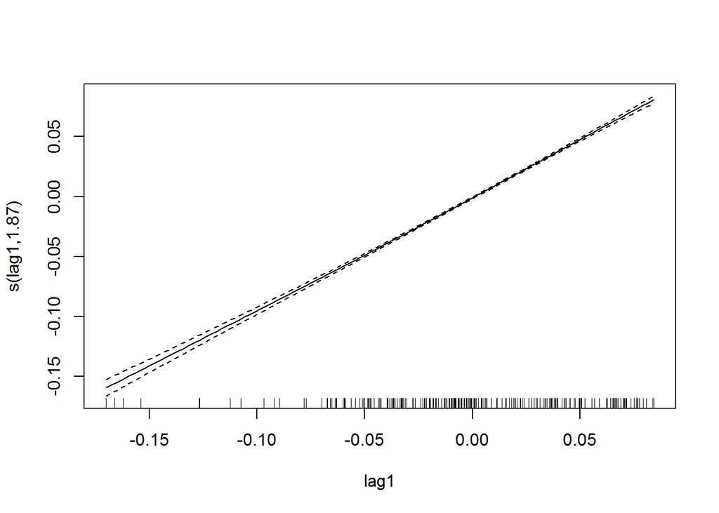

```r
plot(prod.aar1, pages=1)
```

```r
#aar
lag1df <- data.frame("lag1" = macroPost2005Delay$Productivity)
aar1Pred <- predict(prod.aar1, newdata=lag1df)
#linear
macro2005delay$newProd <- macro2005$Productivity[2:nrow(macro2005)]
lm.prod <- glm(newProd~Productivity, data=macro2005delay)
lmp.pred <- predict(lm.prod, newdata=macroPost2005Delay)
#kernel
kreg.prod <- npreg(newProd~Productivity, data=macro2005delay)
```

[output not shown]

```r
krp.pred <- predict(kreg.prod, newdata=macroPost2005Delay)


paste("AAR: ", mean((aar1Pred)^2))
```

```
## [1] "AAR:  0.000590240750538678"
```

```r
paste("Linear Model: ", mean((lmp.pred-macroPost2005Delay$Productivity)^2))
```

```
## [1] "Linear Model:  0.00000231930494842826"
```

```r
paste("Kernel Regression: ", mean((krp.pred-macroPost2005Delay$Productivity)^2))
```

```
## [1] "Kernel Regression:  0.00000458515830071918"
```

# 6: Regression Model of Productivity using Lagged Variables

We begin here by picking a model. To compare linear, GAM, and kernel regression models, we look at their mean squared errors on the testing data (Note: Not the training data as in problems 1-3). Interestingly enough, we find the linear model to be the best predictor on this data, and so we use it.

```r
prodLin <- glm(newProd ~ oldGDP+Consumption+Investment+Hours+Productivity,
              data=macro2005delay)
prodGam <- gam(newProd ~ s(oldGDP)+s(Consumption)+s(Investment)+s(Hours)+s(Productivity),
              data=macro2005delay)
prodKreg <- npreg(newProd ~ oldGDP+Consumption+Investment+Hours+Productivity,
              data=macro2005delay)
```

[output not shown]

```r
prodLinPred <- predict(prodLin, newdata = macroPost2005Delay)
prodGamPred <- predict(prodGam, newdata = macroPost2005Delay)
prodKregPred <- predict(prodKreg, newdata = macroPost2005Delay)
paste("Mean Squared Errors:")
```

```
## [1] "Mean Squared Errors:"
```

```r
paste("Linear Model: ", mean((prodLinPred - macroPost2005Delay$Productivity)^2))
```

```
## [1] "Linear Model:  0.0000574588578058468"
```

```r
paste("General Additive Model: ", mean((prodGamPred - macroPost2005Delay$Productivity)^2))
```

```
## [1] "General Additive Model:  0.000371688208216929"
```

```r
paste("Kernel Regression: ", mean((prodKregPred - macroPost2005Delay$Productivity)^2))
```

```
## [1] "Kernel Regression:  0.000443953120584089"
```

Next we take a look at how the linear model for productivity performs graphically. It is immediately apparent that the linear model is choppier than the previous kernel regressions, but adheres to the testing data more closely.

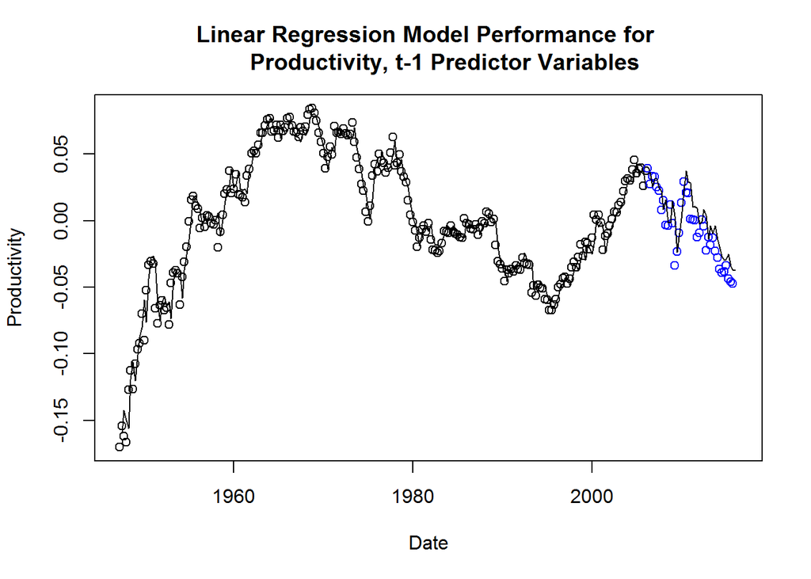

```r
plot(macro$X, macro$Productivity, main="Linear Regression Model Performance for
     Productivity, t-1 Predictor Variables", xlab="Date", ylab="Productivity")
lines(macro2005delay$X, prodLin$fitted.values, col="black")
points(subset(macro, X > "2006-01-01")$X,
       subset(macro, X > "2006-01-01")$Productivity, col="blue")
lines(macroPost2005Delay$X, prodLinPred)
```

```r
paste("AAR: ", mean((aar1Pred)^2))
```

```
## [1] "AAR:  0.000590240750538678"
```

```r
paste("Linear: ", mean((prodLinPred - macroPost2005Delay$Productivity)^2))
```

```
## [1] "Linear:  0.0000574588578058468"
```

Based on our ability to make a pretty accurate model such as the above one from other predictors, we might conclude that Productivity is not an exogenous variable, but rather is endogenous to the dataset in nature.

# 7 (Concluding argument)

The statement “Exogenous changes in productivity are the main driver of the macroeconomic fluctuations” is one which is dubious at best, given the models we have observed here. As we saw in part 6, productivity itself is not exogenous in relation to the other variables in the macro dataset, which hints right away that there is some interconnectedness between all the endogenous variables. Inspection of models created in problems 1-4 showed that variables other than Productivity had statistically significant effects on estimating future GDP, in both kernel regression and GAM models. Thus, while exogenous changes in productivity do likely play a role in macroeconomic fluctuation, it would be unwise to attribute them as the main drivers of said fluctuation.